# Musterloesung Übung 8

Statistik8

## Musterloesung Aufgabe 8.1: Clusteranalysen

- R-Skript als Download
- Loesungstext

## Übungsaufgabe

*(hier so ausführlich formuliert, wie dies auch in der Klausur der Fall sein wird)*

- Ladet den Datensatz crime2.csv. Dieser enthält Raten von 7 Kriminatlitätsformen pro 100000 Einwohner und Jahr für die Bundesstaaten der USA.
- Führt eine k-means- und eine agglomerative Clusteranalyse eurer Wahl durch. Bitte beachet, dass wegen der sehr ungleichen Varianzen in jedem Fall eine Standardisierung stattfinden muss, damit die Distanzen zwischen den verschiedenen Kriminalitätsraten sinnvoll berechnet werden können.
- **Überlegt in beiden Fällen, wie viele Cluster sinnvoll sind** (k-means: z. B. visuelle Betrachtung einer PCA, agglomertive Clusteranalyse: z. B. Silhoutte-Plot).
- Entscheidet euch dann für eine der beiden Clusterungen und vergleicht dann die erhaltenen Cluster bezüglich der Kriminalitätsformen und interpretiert die Cluster entsprechend.
- Bitte erklärt und begründet die einzelnen Schritte, die ihr unternehmt, um zu diesem Ergebnis zu kommen. Dazu erstellt bitte ein Word-Dokument, in das ihr Schritt für Schritt den verwendeten R-Code, die dazu gehörigen Ausgaben von R, eure Interpretation derselben und die sich ergebenden Schlussfolgerungen für das weitere Vorgehen dokumentieren.
- Formuliert abschliessend einen Methoden- und Ergebnisteil (ggf. incl. adäquaten Abbildungen) zu dieser Untersuchung in der Form einer wissenschaftlichen Arbeit (ausformulierte schriftliche Zusammenfassung, mit je einem Absatz von ca. 60-100 Worten, resp. 3-8 Sätzen für den Methoden- und Ergebnisteil). D. h. alle wichtigen Informationen sollten enthalten sein, unnötige Redundanz dagegen vermieden werden.
- **Abzugeben sind am Ende (a) Ein lauffähiges R-Skript; (b) begründeter Lösungsweg (Kombination aus R-Code, R Output und dessen Interpretation) und (c) ausformulierter Methoden- und Ergebnisteil (für eine wiss. Arbeit).**

### Uebung 8.1 - Clusteranalysen – Loesung

```r
crime <- read.csv("crime2.csv", sep = ";")
```

```r
crime
```

[output not shown]

Im mitgelieferten R-Skript habe ich die folgenden Analysen zunächst mit untransformierten, dann mit standardisierten Kriminalitätsraten berechnet. Ihr könnt die Ergebnisse vergleichen und seht, dass sie sehr unterschiedlich ausfallen.

```r
crimez <- crime
crimez[,c(2:8)] <- lapply(crime[, c(2:8)], scale)
crimez
```

```
    X      Murder        Rape       Robbery     Assault     Burglary
1  ME -1.38246619 -1.31559240 -1.0464120463 -1.24765744 -0.938630226
2  NH -1.32457397 -0.85298774 -1.0830960795 -1.31950227 -1.053079880
3  VT -1.38246619 -0.83227410 -1.1014380961 -1.24047295 -0.590512528
4  MA -0.91932843 -0.28681488  0.4668043222  0.39758933 -0.299619657
5  RI -0.94827454 -0.85989229 -0.2118502916 -0.60105391  0.232094361
6  CT -0.62986734 -0.69418316  0.4576333139 -0.50765562  0.003195053
7  NY  1.13584533 -0.23157851  3.4106979845  1.11603770  0.058035512
8  NJ -0.45619068 -0.04515574  1.1638009525 -0.07658660 -0.299619657
9  PA -0.36935236 -0.60442405  0.0907929821 -0.71600564 -1.100767236
10 OH -0.36935236  0.32768980 -0.0009171008 -0.29212111 -0.497522184
11 IN -0.22462181 -0.54918767 -0.4778095321 -0.64416081 -0.738343331
12 IL  0.61481536 -0.10039211  1.6773774169  1.13759115 -0.039723567
13 MI  1.30952199  2.31619936  1.4572732179  1.06574631  0.744733437
14 WI -1.06405898 -0.94965140 -0.6337166731 -0.81658842 -0.986317582
```

[output cut: 87 more lines]

„scale“ führt eine Standardisierung (z-Transformation) durch, so dass alle Variablen anschiessen einen Mittelwert von 0 und eine SD von 1 haben, ausgenommen natürlich die 1. Spalte mit den Kürzeln der Bundesstaaten. Anschliessend wird das SSI-Kriterium getestet und zwar für Partitionierungen von 2 bis 6 Gruppen (wie viele Gruppen man maximal haben will, muss man pragmatisch nach der jeweiligen Fragestelltung entscheiden).

```r
library(vegan)
crimez.KM.cascade <- cascadeKM(crimez[,c(2:8)],
                        inf.gr = 2, sup.gr = 6, iter = 100, criterion = "ssi")
summary(crimez.KM.cascade)
```

```
          Length Class  Mode
partition 250    -none- numeric
results    10    -none- numeric
criterion   1    -none- character
size       30    -none- numeric
```

```r
crimez.KM.cascade$results
```

```
      2 groups   3 groups   4 groups   5 groups  6 groups
SSE 174.959159 144.699605 124.437221 108.119280 95.316398
ssi   1.226057   1.304674   1.555594   1.539051  1.351146
```

```r
crimez.KM.cascade$partition
```

```
   2 groups 3 groups 4 groups 5 groups 6 groups
1         1        2        3        1        6
2         1        2        3        1        6
3         1        2        3        1        6
4         2        1        1        4        1
5         1        1        2        4        1
6         1        1        2        4        2
7         2        1        1        2        3
8         2        1        1        4        1
9         1        2        2        5        2
10        1        1        2        5        2
11        1        2        2        5        2
12        2        1        1        2        3
13        2        3        4        2        5
14        1        2        3        1        6
```

[output cut: 36 more lines]

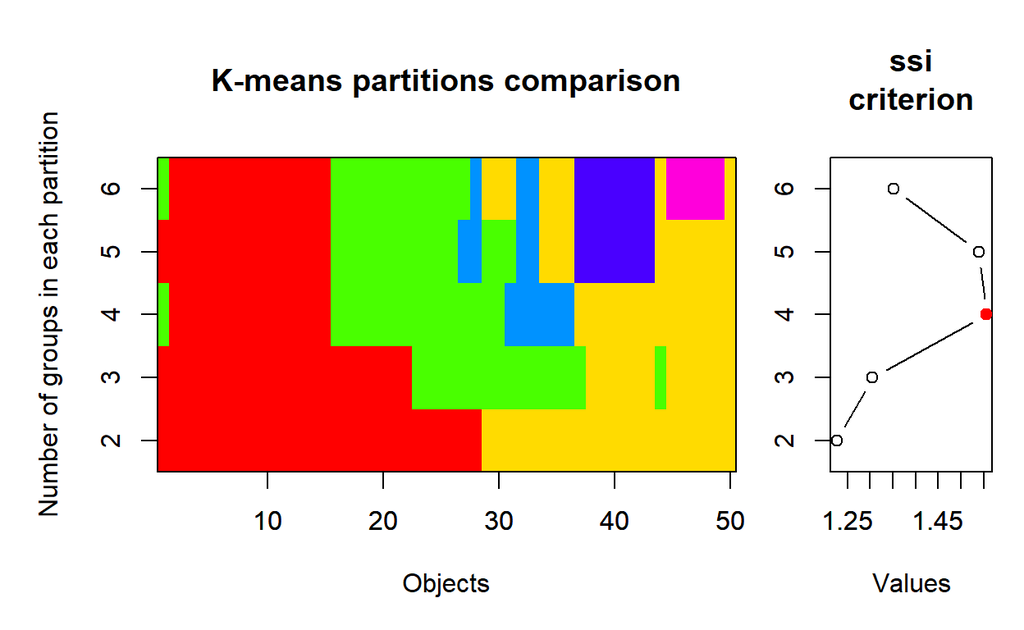

```r
# k-means visualisation
library(cclust)
plot(crimez.KM.cascade, sortg = TRUE)
```

Nach SSI ist die 4-Gruppenlösung die beste, mit dieser wird also weitergerechnet.

```r
# 4 Kategorien sind nach SSI offensichtlich besonders gut
modelz <- kmeans(crimez[,c(2:8)], 4)
modelz
```

```
K-means clustering with 4 clusters of sizes 6, 16, 14, 14

Cluster means:
        Murder       Rape    Robbery    Assault     Burglary
1  0.344651676  0.1527746  1.4679727  0.6670075 -0.006342418
2 -0.002098593 -0.2436615 -0.2668763 -0.1457373 -0.279054485
3 -1.088869933 -0.9575423 -0.9573223 -1.0018455 -0.966220768
4  0.943560464  1.1705377  0.6331926  0.8825420  1.287858358
       Theft    Vehicle
1 -0.3396250  1.3846917
2 -0.5371659 -0.3276196
3 -0.3729397 -0.9310433
4  1.1323972  0.7120264

Clustering vector:
 [1] 3 3 3 1 2 2 1 1 2 2 2 1 4 3 3 3 2 3 3 3 2 2 1 2 3 2 2 4 4 2 1 2 2
[34] 2 4 4 4 3 3 3 4 4 4 3 4 4 4 4 4 2

Within cluster sum of squares by cluster:
[1] 16.59050 39.51883 19.37307 48.95481
 (between_SS / total_SS =  63.7 %)

Available components:

[1] "cluster"      "centers"      "totss"        "withinss"
[5] "tot.withinss" "betweenss"    "size"         "iter"
[9] "ifault"
```

```r
#File für ANOVA (Originaldaten der Vorfälle, nicht die ztransformierten)
crime.KM4 <- data.frame(crime,modelz[1])
crime.KM4$cluster <- as.factor(crime.KM4$cluster)
crime.KM4
```

```
    X Murder Rape Robbery Assault Burglary Theft Vehicle cluster
1  ME    2.0 14.8      28     102      803  2347     164       3
2  NH    2.2 21.5      24      92      755  2208     228       3
3  VT    2.0 21.8      22     103      949  2697     181       3
4  MA    3.6 29.7     193     331     1071  2189     906       1
5  RI    3.5 21.4     119     192     1294  2568     705       2
6  CT    4.6 23.8     192     205     1198  2758     447       2
7  NY   10.7 30.5     514     431     1221  2924     637       1
8  NJ    5.2 33.2     269     265     1071  2822     776       1
9  PA    5.5 25.1     152     176      735  1654     354       2
10 OH    5.5 38.6     142     235      988  2574     376       2
11 IN    6.0 25.9      90     186      887  2333     328       2
12 IL    8.9 32.4     325     434     1180  2938     628       1
13 MI   11.3 67.4     301     424     1509  3378     800       4
14 WI    3.1 20.1      73     162      783  2802     254       3
```

[output cut: 36 more lines]

```r
str(crime.KM4)
```

```
'data.frame':   50 obs. of  9 variables:
 $ X       : chr  "ME" "NH" "VT" "MA" ...
 $ Murder  : num  2 2.2 2 3.6 3.5 4.6 10.7 5.2 5.5 5.5 ...
 $ Rape    : num  14.8 21.5 21.8 29.7 21.4 23.8 30.5 33.2 25.1 38.6 ...
 $ Robbery : int  28 24 22 193 119 192 514 269 152 142 ...
 $ Assault : int  102 92 103 331 192 205 431 265 176 235 ...
 $ Burglary: int  803 755 949 1071 1294 1198 1221 1071 735 988 ...
 $ Theft   : int  2347 2208 2697 2189 2568 2758 2924 2822 1654 2574 ...
 $ Vehicle : int  164 228 181 906 705 447 637 776 354 376 ...
 $ cluster : Factor w/ 4 levels "1","2","3","4": 3 3 3 1 2 2 1 1 2 2 ...
```

**Von den agglomerativen Clusterverfahren habe ich mich für Ward’s minimum variance clustering entschieden, da dieses allgemein als besonders geeignet gilt.**

Vor der Berechnung von crime.norm und crime.ch muss man die Spalte mit den Bundesstaatenkürzeln entfern.

```r
#Agglomerative Clusteranalyse
crime2 <- crime[,-1]
crime.norm <- decostand(crime2, "normalize")
crime.ch <- vegdist(crime.norm, "euc")
# Attach site names to object of class 'dist'
attr(crime.ch, "Labels") <- crime[,1]

#Ward's minimum variance clustering
crime.ch.ward <- hclust(crime.ch, method = "ward.D2")
par(mfrow = c(1, 1))
plot(crime.ch.ward, labels = crime[,1], main = "Chord - Ward")

# Choose and rename the dendrogram ("hclust" object)
hc <- crime.ch.ward
# hc <- spe.ch.beta2
# hc <- spe.ch.complete
dev.new(title = "Optimal number of clusters", width = 12, height = 8, noRStudioGD = TRUE)
dev.off()
par(mfrow = c(1, 2))


# Average silhouette widths (Rousseeuw quality index)
library(cluster)
Si <- numeric(nrow(crime))
for (k in 2:(nrow(crime) - 1))
{
 sil <- silhouette(cutree(hc, k = k), crime.ch)
 Si[k] <- summary(sil)$avg.width
}
k.best <- which.max(Si)
plot( 1:nrow(crime), Si, type = "h",
 main = "Silhouette-optimal number of clusters",
 xlab = "k (number of clusters)", ylab = "Average silhouette width")

axis(1, k.best, paste("optimum", k.best, sep = "\n"), col = "red",
 font = 2, col.axis = "red")
points(k.best, max(Si), pch = 16, col = "red", cex = 1.5)
```

[output not shown]

Demnach wären beim Ward’s-Clustering nur zwei Gruppen die optimale Lösung.

**Für die Vergleiche der Bundesstaatengruppen habe ich mich im Folgenden für die k-means Clusterung mit 4 Gruppen entschieden.**

Damit die Boxplots und die ANOVA direkt interpretierbar sind, werden für diese, anders als für die Clusterung, die untransformierten Incidenz-Werte verwendet (also crime statt crimez). Die Spalte mit der Clusterzugehörigkeit im Fall von k-means mit 4 Clustern hängt man als Spalte an (Achtung: muss als Faktor definiert werden!).

Anschliessend kann man die 7 ANOVAs rechnen, die Posthoc-Vergleiche durchführen und die zugehörigen Boxplots mit Buchstaben für die homogenen Gruppen erzeugen. Sinnvollerweise gruppiert man die Abbildungen gleich, z. B. je 2 x 2. Das Skript ist hier simple für jede Verbrechensart wiederholt. Erfahrenere R-Nutzer können das Ganze hier natürlich durch eine Schleife abkürzen.

```r
library(multcomp)
if(!require(multcomp)){install.packages("multcomp")}
library(multcomp)
par(mfrow = c(3,3))

ANOVA.Murder <- aov(Murder~cluster, data = crime.KM4)
summary(ANOVA.Murder)
```

```
            Df Sum Sq Mean Sq F value   Pr(>F)
cluster      3  355.4  118.46   23.75 1.96e-09 ***
Residuals   46  229.4    4.99
---
Signif. codes:  0 '***' 0.001 '**' 0.01 '*' 0.05 '.' 0.1 ' ' 1
```

```r
letters <- cld(glht(ANOVA.Murder, linfct = mcp(cluster = "Tukey")))
boxplot(Murder~cluster, xlab = "Cluster", ylab = "Murder", data = crime.KM4)
mtext(letters$mcletters$Letters, at = 1:6)

ANOVA.Rape <- aov(Rape~cluster,data = crime.KM4)
summary(ANOVA.Rape)
```

```
            Df Sum Sq Mean Sq F value   Pr(>F)
cluster      3   6945  2315.0   31.95 2.58e-11 ***
Residuals   46   3333    72.5
---
Signif. codes:  0 '***' 0.001 '**' 0.01 '*' 0.05 '.' 0.1 ' ' 1
```

```r
letters <- cld(glht(ANOVA.Rape, linfct = mcp(cluster = "Tukey")))
boxplot(Rape~cluster, xlab = "Cluster", ylab = "Rape", data = crime.KM4)
mtext(letters$mcletters$Letters, at = 1:6)

ANOVA.Robbery <- aov(Robbery~cluster, data = crime.KM4)
summary(ANOVA.Robbery)
```

```
            Df Sum Sq Mean Sq F value   Pr(>F)
cluster      3 386563  128854   30.24 5.96e-11 ***
Residuals   46 196025    4261
---
Signif. codes:  0 '***' 0.001 '**' 0.01 '*' 0.05 '.' 0.1 ' ' 1
```

```r
letters <- cld(glht(ANOVA.Robbery, linfct = mcp(cluster = "Tukey")))
boxplot(Robbery~cluster, xlab = "Cluster", ylab = "Robbery", data = crime.KM4)
mtext(letters$mcletters$Letters, at = 1:6)

ANOVA.Assault <- aov(Assault~cluster, data = crime.KM4)
summary(ANOVA.Assault)
```

```
            Df Sum Sq Mean Sq F value   Pr(>F)
cluster      3 541786  180595   20.39 1.51e-08 ***
Residuals   46 407517    8859
---
Signif. codes:  0 '***' 0.001 '**' 0.01 '*' 0.05 '.' 0.1 ' ' 1
```

```r
letters <- cld(glht(ANOVA.Assault, linfct = mcp(cluster = "Tukey")))
boxplot(Assault~cluster, xlab = "Cluster", ylab = "Assault",  data = crime.KM4)
mtext(letters$mcletters$Letters, at = 1:6)

ANOVA.Burglary <- aov(Burglary~cluster, data = crime.KM4)
summary (ANOVA.Burglary)
```

```
            Df  Sum Sq Mean Sq F value  Pr(>F)
cluster      3 6602474 2200825   50.21 1.5e-14 ***
Residuals   46 2016382   43834
---
Signif. codes:  0 '***' 0.001 '**' 0.01 '*' 0.05 '.' 0.1 ' ' 1
```

```r
letters <- cld(glht(ANOVA.Burglary, linfct=mcp(cluster = "Tukey")))
boxplot(Burglary~cluster, data = crime.KM4, xlab = "Cluster", ylab = "Burglary")
mtext(letters$mcletters$Letters, at=1:6)

ANOVA.Theft <- aov(Theft~cluster, data = crime.KM4)
summary(ANOVA.Theft)
```

```
            Df   Sum Sq Mean Sq F value   Pr(>F)
cluster      3 14249791 4749930   16.25 2.44e-07 ***
Residuals   46 13448760  292364
---
Signif. codes:  0 '***' 0.001 '**' 0.01 '*' 0.05 '.' 0.1 ' ' 1
```

```r
letters <- cld(glht(ANOVA.Theft, linfct = mcp(cluster = "Tukey")))
boxplot(Theft~cluster, xlab = "Cluster", ylab = "Theft", data = crime.KM4)
mtext(letters$mcletters$Letters, at = 1:6)

ANOVA.Vehicle <- aov(Vehicle~cluster, data = crime.KM4)
summary(ANOVA.Vehicle)
```

```
            Df  Sum Sq Mean Sq F value   Pr(>F)
cluster      3 1427939  475980   30.08 6.46e-11 ***
Residuals   46  727932   15825
---
Signif. codes:  0 '***' 0.001 '**' 0.01 '*' 0.05 '.' 0.1 ' ' 1
```

[figure not shown]

```r
letters <- cld(glht(ANOVA.Vehicle, linfct = mcp(cluster = "Tukey")))
boxplot(Vehicle~cluster, data = crime.KM4, xlab = "Cluster", ylab = "Vehicle")
mtext(letters$mcletters$Letters, at = 1:6)
```

Die Boxplots erlauben jetzt auch eine Beurteilung der Modelldiagnostik: sind die Residuen hinreichen normalverteilt (symmetrisch) und sind die Varianzen zwischen den Kategorien einigermassen ähnlich. Mit der Symmetrie/Normalverteilung sieht es OK aus. Die Varianzhomogenität ist nicht optimal – meist deutlich grössere Varianz bei höheren Mittelwerten. Eine log-Transformation hätte das verbessert und könnte hier gut begründet werden. Da die p-Werte sehr niedrig waren und die Varianzheterogenität noch nicht extrem war, habe ich aber von einer Transformation abgesehen, da jede Transformation die Interpretation der Ergebnisse erschwert. Jetzt muss man nur noch herausfinden, welche Bundesstaaten überhaupt zu welchem der vier Cluster gehören, sonst ist das ganze schöne Ergebnis nutzlos. Z. B. kann man in R auf den Dataframe clicken und ihn nach cluster sortieren.